# Cumulative Biomass example

Author

MZ https://github.com/matzuc

This notebook is available at https://github.com/matzuc

## Dependancies

loading required packages for running the example. For fitting the curves and estimating the parameters, only the `drc` package is needed.

```r
library(drc)
library(dplyr) # data handling
library(tidyr) # data handling
library(purrr) # data handling
library(ggplot2) # plotting
library(ggthemes) # plotting
library(viridis) # plotting
library(here) # handling paths
library(rfishbase) #for retrieving TLs from fishbase
```

## Loading the dataset

We use reconstructed catches from Sea Around Us (https://www.seaaroundus.org/) for the EEZs of Italy downloaded in March 24<sup>th</sup> 2023.

```r
db <- read.csv(here('data/SAU EEZ 380,901,902 v50-0.csv'), sep = ",", dec = ".")
```

## Data handling

Normally you can use multiple local and specific sources to obtains trophic levels (TLs) for the species, but in this example we use the TLs from fishbase, retrieved with the `rfishbase` package.

First we extract the list of species in the dataset.

```r
splist <- db |> group_by(scientific_name, common_name) |> summarise()
```

We use the function `ecology` from `rfishbase` to extract the TL

```r
fb <- ecology(splist$scientific_name,
        fields=c("Species", "FoodTroph", "FoodSeTroph")) |> rename(scientific_name = Species)
```

Check for duplicates in retrived TLs

```r
fb %>% group_by(scientific_name) %>% filter(n() > 1)
```

```
# A tibble: 2 × 3
# Groups:   scientific_name [1]
  scientific_name   FoodTroph FoodSeTroph
  <chr>                 <dbl>       <dbl>
1 Sprattus sprattus      3.01        0.07
2 Sprattus sprattus     NA          NA
```

We can remove the onw without TL information

```r
fb <- fb |> filter(!((scientific_name == "Sprattus sprattus") & is.na(FoodTroph)))
```

We obtain TLs for 100 species out of 224 taxa in the dataset. We will remove the taxa without TL for this examples, but this operation should be carefully evaluated in a real-world analysis.

We attach the TLs to the catches dataset and remove record without TL

```r
db <-  left_join(db, fb)
dat <- db |> filter(!is.na(FoodTroph ))
```

### Cumulating biomass

We group the TLs in TL classes, choosing a 0.1 step, and cumulating the biomass for each TL class, groupting for EEZ and year

```r
# TL step
step <- 0.1

#TL range
my.lim <- seq(1-step, 5.4 +step,by=step)

#TL labels (midpoint of the class)
my.lab <- my.lim + step/2


# factor
dat$fTL <- cut(dat$FoodTroph , my.lim, labels=my.lab[-length(my.lim)])

# numeric label for the TL class
dat$fTLr <- as.numeric(levels(dat$fTL)[dat$fTL])
```

Cumulated biomass for TL class

```r
cumbio <- dat |>
    group_by(area_name, year, fTLr) |>
    summarise(B = sum(tonnes)) |> # total biomass for TL class
    ungroup(fTLr) |>
    arrange(area_name, year, fTLr) |> # order by TL
    mutate(ycum = cumsum(B)) |> # cumulative biomass
    mutate(ycurv = ycum / max(ycum)) #relative cumulative biomass
```

We can plot all the curves to compare the different zones, or to see if they cange over time.

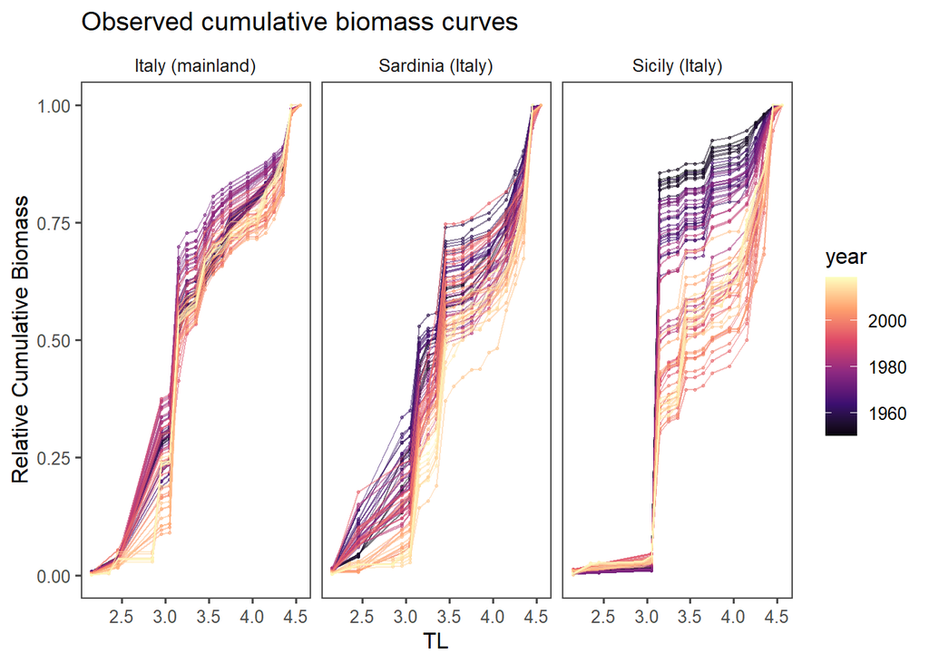

```r
ggplot(cumbio, aes(fTLr, ycurv, colour = year, group = (year))) +
    geom_point(alpha = 0.5, size = 0.6) +
    geom_line(alpha = 0.5) +
    facet_grid(.~ area_name) +
    scale_color_viridis_c(option = "magma") +
    theme_few() +
    xlab("TL") +
    ylab("Relative Cumulative Biomass") +
    ggtitle("Observed cumulative biomass curves")
```

or just focus on one curve:

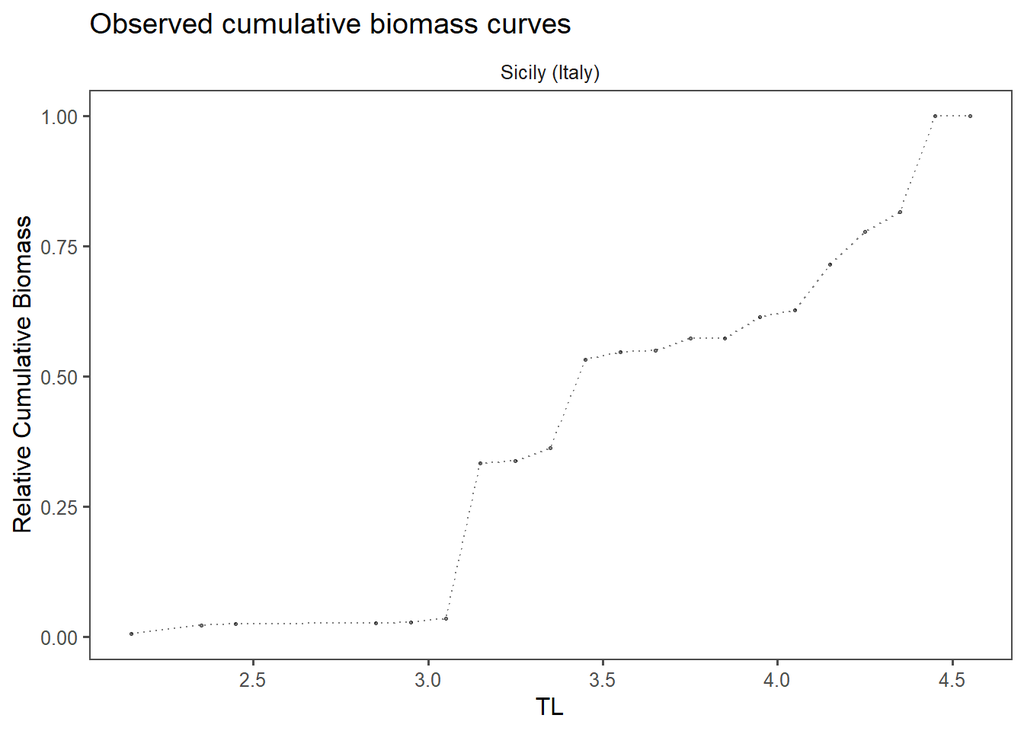

```r
ex <- cumbio |> filter(area_name == "Sicily (Italy)", year == 2015)

ex_plot <- ggplot(ex, aes(fTLr, ycurv)) +
    geom_point(alpha = 0.5, size = 0.6) +
    geom_line(alpha = 0.5, lty = 3) +
    facet_grid(.~ area_name) +
    theme_few() +
    xlab("TL") +
    ylab("Relative Cumulative Biomass") +
    ggtitle("Observed cumulative biomass curves")

print(ex_plot)
```

## Fit the curves and extract the parameters

we can leverage the `baro5` function from the `drc` package to fit the baroreflex 5-parameter function to the TL/ relative cumulative biomass relationship

We can define a function to fit the model (fixing the upper asymptote to 1), and extract some parameters to summarize the characteristics of the curve

```r
mycurve <- function(x, y, npoints = 10000){

    # fit the model
  r <- drm(y ~ x, fct = baro5(fixed = c(NA, NA, NA, 1, NA)))

  # use the fitted curve to predict the expected values (these are used fot plotting and estimating the parameters)

  # xx are the TLs
  xx <- NA;
  xx <- seq(1.6, 5,length.out = npoints)
  pr <- NA; length(pr) <- npoints# vector for prediction
  pr <- predict(r, newdata = data.frame(x = xx))

  # parameters

  dpr<-diff(pr,1)/diff(xx)

  # TL @ inflection point
  TLinfl <- xx[which.max(dpr)-1]
  # maximum steepness
  Steepness <- max(dpr)
  # Biomass @ inflection
  BIOinfl<- predict(r, newdata=data.frame(x = TLinfl))
  # Lower asymptote
  LowA <- predict(r, newdata=data.frame(x=1))




  results <- list(
    curve = data.frame(x = xx, y = pr),
    parameters =    data.frame(LowA = LowA, Steepness = Steepness, TLinfl = TLinfl, BIOinfl = BIOinfl)
  )

  return(results)


}
```

We use the function on the small example

```r
out_ex <- mycurve(ex$fTLr, ex$ycurv)
```

And see how the curve looks like

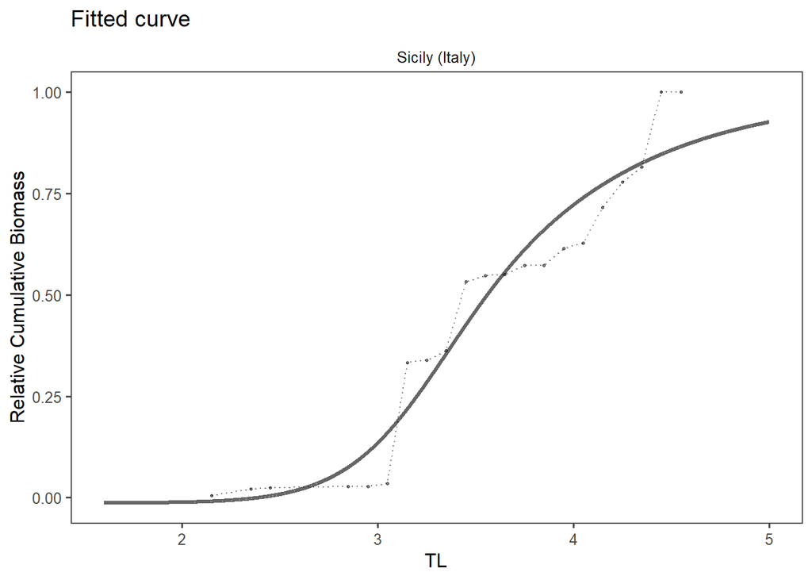

```r
ex_plot <- ex_plot +
    geom_line(data = out_ex$curve, aes(x = x, y = y), size = 1.1, alpha = 0.6) +
    ggtitle("Fitted curve")
print(ex_plot)
```

We can also visualize the extracted parameters

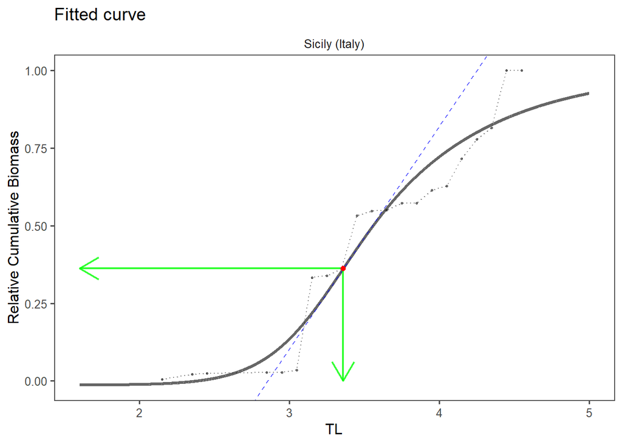

```r
intercept <- out_ex$parameters$BIOinfl - out_ex$parameters$Steepness * out_ex$parameters$TLinfl

ex_plot <- ex_plot  +
    geom_abline(aes(intercept = intercept, slope = out_ex$parameters$Steepness), colour = "blue", lty = 2, alpha = 0.8) +
    geom_segment(data = out_ex$parameters, aes(x = TLinfl, y = BIOinfl,
                                     xend = min(out_ex$curve$x), yend = BIOinfl), size = 0.8, lty = 1, alpha = 0.8, colour = "green", arrow=arrow()) +
    geom_segment(data = out_ex$parameters, aes(x = TLinfl, y = BIOinfl,
                                     xend = TLinfl, yend = 0), size = 0.8, lty = 1, alpha = 0.8, colour = "green", arrow=arrow()) +
    geom_point(data = out_ex$parameters, aes(x = TLinfl, y = BIOinfl), colour = "red", size = 1.6)

print(ex_plot)
```

the function can be used also on the time series

```r
out_pars <- cumbio |>
    group_by(area_name, year) |>
    summarise(LowA = mycurve(fTLr, ycurv)$parameters$LowA,
                        Steepness = mycurve(fTLr, ycurv)$parameters$Steepness,
                        TLinfl = mycurve(fTLr, ycurv)$parameters$TLinfl,
                        BIOinfl = mycurve(fTLr, ycurv)$parameters$BIOinfl)
```

We can plot the time series of the parameters

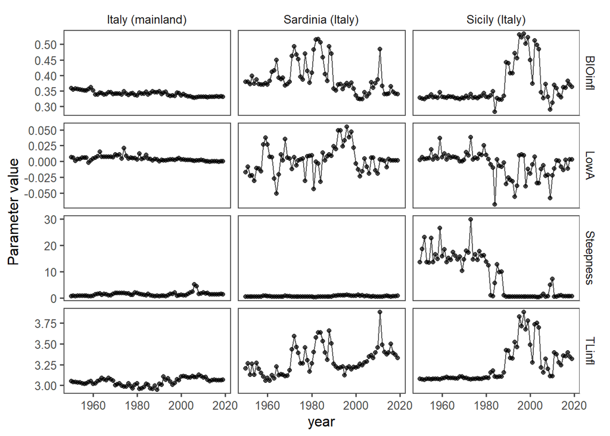

```r
longdata <- out_pars |>
  tidyr::gather(variable, value, c(LowA, Steepness, TLinfl, BIOinfl)) %>%
  group_by(area_name, year) %>%
  #summarise(mean_value = mean(value)) %>%
  ungroup()

ggplot(longdata, aes(year, value)) +
    geom_point(alpha = 0.7) +
    geom_line(alpha = 0.7) +
    facet_grid(variable ~ area_name, scale = "free_y") +
    theme_few() +
    ylab("Parameter value")
```

We can also extract all the fitted curves and plot them

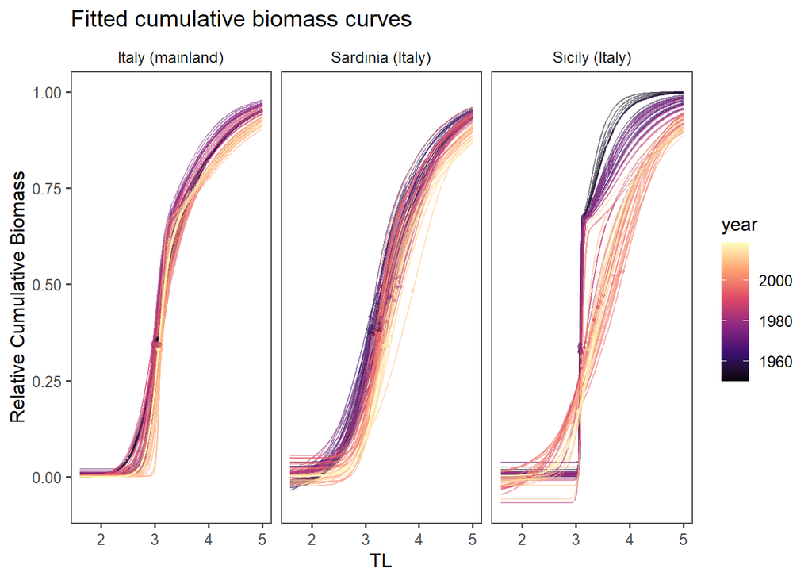

```r
b_curves <- cumbio  %>%
  # Group the data by area_name and year
  group_by(area_name, year) %>%
  # Split the data into a list of data frames based on the grouping
  group_split() %>%
  # Apply the mycurve function to each data frame in the list
  map(function(df) {
    # Apply the function using fTLr as x and ycurv as y
    res <- mycurve(df$fTLr, df$ycurv, npoints = 100)

    # Extract the curve data frame
    curve <- res$curve

    # Add area_name and year columns to the curve data frame
    curve$area_name <- unique(df$area_name)
    curve$year <- unique(df$year)

    # Return the curve data frame
    curve
  }) %>%
  # Combine the curve data frames from each list element
  bind_rows()


ggplot(b_curves, aes(x, y, colour = year, group = (year))) +
    geom_line(alpha = 0.5) +
    facet_grid(.~ area_name) +
    scale_color_viridis_c(option = "magma") +
    theme_few() +
    xlab("TL") +
    ylab("Relative Cumulative Biomass") +
    ggtitle("Fitted cumulative biomass curves") +
    geom_point(data = out_pars, aes(x = TLinfl, y =  BIOinfl), alpha = 0.4, size = 0.7)
```